# Computing the Posterior Probability Distribution on the Effect Size \( \beta_{gp} \)

Following directly from the documentation on GitHub (configmodel), by maximum likelihood in each tissue separately, we can easily obtain the estimates of the standardized genotype effect sizes, \( \hat{\beta}_{gp} \), and their standard errors recorded on the diagonal of an \( R \times R \) matrix noted \( \hat{V}_{gp} = Var(\hat{\beta}_{gp}) \).

This will be input by the user according to the summary stats function in eqtlbmaa_bf, as shown below with a sample from the tutorial. Here, the number of tissues was 9.

```r
install.packages("mvtnorm")
```

```
## Error: trying to use CRAN without setting a mirror
```

```r
library("mvtnorm")
nts=9
nb.snps=10250
path=("~/Desktop/new_tutorial/")
setwd(path)
sum.stats=sapply(seq(1:nts),function(x){paste0(path,"out_eqtlbma_sumstats_tissue",x,".txt.gz",sep="")})
sum.stat=list(NULL)
beta.hat=list(NULL)
sigma.hat=list(NULL)
for(i in 1:nts){
  df=read.table(sum.stats[i],header=T)
  sum.stat[[i]]=df
  beta.hat[[i]]=df$betahat.geno
  sigma.hat[[i]]=df$sebetahat.geno
}
```

Using each pair of tissues, we can also fill the off-diagonal elements of \( \hat{V}_{gp} \). However, if the tissues arose from different studies, we may not have these covariance estimates available, and so we will specify that \( \hat{V}_{gp} \) is diagonal for simplicity. If we now view \( \hat{\beta}_{gp} \) and \( \hat{V}_{gp} \) as *observations* (i.e. known), we can *forget* about the original data \( X_p,X_c \) and \( Y_g \), and write a new **likelihood** (using only the sufficient statistics):

\( \hat{\beta}_{gp} | \beta_{gp} \sim Norm_R(\beta_{gp}, \hat{V}_{gp}) \)

Let us imagine first that the prior on \( \beta_{gp} \) is not a mixture but a single Normal: \( \beta_{gp} \sim Norm_R(\mathbf{0}, U_{gp0}) \). As this prior is conjuguate to the “likelihood'' above, the posterior simply is:

\( \beta_{gp} | \hat{\beta}_{gp} \sim Norm_R({\mu}_{gp1}, U_{gp1}) \)

where:

\( \mu_{gp1} = U_{gp1} (\hat{V}_{gp}^{-1} \hat{\beta}_{gp}) \); \( U_{gp1} = (U_{gp0}^{-1} + \hat{V}_{gp}^{-1})^{-1} \).

In practice, we use a mixture for prior:

\( \mathbf\beta_{gp} \) | \( \lambda \), \( \mathbf U_{gp0j} \) \( \sim \sum_{l=1}^L \lambda_l \; Norm_R({0}, U_{gp0jl}) \)

for which the hyper-parameters are either fixed (\( \mathbf U_{gp0j} \)) or estimated (\( \lambda \)) as described using the full hierarchical model and the EM algorithm. Moreover, the posteriors we seek are \( {\beta}_{gp} \) | \( \hat{\beta}_{gp} \), \( \hat{V}_{gp} \), \( \hat{\theta} \) (full marginal) or \( {\beta}_{gp} \) | \( \hat{\beta}_{gp} \), \( \hat{V}_{gp} \), \( \hat{\Theta}_{-\pi_0} \), \( v_{gp}=1 \) (conditional on being the eQTN in at least one tissue, averaging over all configurations and whole grid) or \( \beta_{gp} \) | \( \hat{\beta}_{gp} \), \( \hat{V}_{gp} \), \( \hat{\lambda} \), \( \gamma_{gpr}=1 \) (conditional on being an active eQTN in tissue \( r \), averaging over all configurations in which this tissue is active and whole grid) or \( {\beta}_{gp} \) | \( \hat{\beta}_{gp} \), \( \hat{V}_{gp} \), \( \hat{\lambda} \), \( c_{gpj}=1 \) (conditional on being the eQTN and in configuration \( j \), averaging over whole grid)$.

Below, we read in the prior grid weights and the corresponding combinations of heterogeneity, \( \phi \) and \( \omega \).

```r
######Initialize Grid vals###
prior.grid=read.table("grid_weights.txt",header=F)
grid.vals=read.table("grid_phi2_oma2_with-configs.txt",header=F)
colnames(grid.vals)=c("phi2","omega2")
prior.func=function(grid.vals,nts){
    ugpo=list(NULL)
    for(i in 1:length(grid.vals[,1])){##create a prior variance matrix for each set of grid values
  ugpo[[i]]=matrix(rep(grid.vals[i,2],nts),ncol=nts,nrow=nts)+diag(rep(grid.vals[i,1],nts))}
  return(ugpo)
  }
ugpo=prior.func(grid.vals,9)
```

Thus, the object *ugpo* now contains the 10 prior variance matrices for 9 tissues incroporating the values of \( \phi \) and \( \omega \) specified by our list of grid weights. Now, for each SNP-Gene Pair, we must consider the posterior distribution of effect sizes among the prespecified variety of grid sizes. Thus for every component, we will have l posterior distributions on \( \beta_{gp} \) ~ \( \hat{b}_{gp} \sim Norm_R({\mathbf \mu}_{gp1}, U_{gp1}) \) and a corresponding set of posterior weights where each weight is proportion to the prior weight \( \hat{lambda} \) and the probability of the data under all possible grid combinations.

\( \sum_{l=1}^L \hat{\lambda}_l \frac { Norm_R(\beta_{gp}|\mathbf{\mu_{gp1jl}}, U_{gp1jl})} {\sum_{l=1}^L \hat{\lambda}_l Norm_R(\hat{\beta}_{gp}|0, U_{gp0l} + \hat{V}_{gp})} \)

Below, I create a function that, given a user-specified SNP-Gene pair, returns a vector of posterior weights and a list of posterior mean vectors and variance from this mixture distribution for every component.

```r
mixture.dist=function(p,nts){
  Id=diag(rep(1,nts))

  b.obs=unlist(lapply(beta.hat,function(x){return(x[p])}))###return beta  hats for gene-SNP pair across tissues
  sigma.obs=as.matrix(diag(unlist(lapply(sigma.hat,function(x){return(x[p])})),ncol=nts))###return sigma hats for gene-SNP pair across tissues
  pdata.l=(prior.grid*unlist(lapply(ugpo,function(x)(dmvnorm(b.obs,mean=rep(0,nts),sigma=x+sigma.obs))))) ##compute grid-specific pdatas
  pdata.total=sum(pdata.l)###compute pdata total
  post.ugp1=(lapply(ugpo,function(x) (solve(Id+x%*%solve(sigma.obs))%*%x)))##compute the posterior variance for each grid weight combo
  v.inv.beta.hat=solve(sigma.obs)%*%b.obs###helpful for posterior mean computation
  mu.gp1=lapply(post.ugp1,function(x)(x%*%v.inv.beta.hat))###Compute a list of expected posterior means vectors for each grid-weight combo
  post.weight=as.vector(unlist(prior.grid/pdata.total))
  post.weight=as.matrix(post.weight,nrow=1)
  return(list(component.means=mu.gp1,component.vars=post.ugp1,posterior.weights=unlist(post.weight)))}
```

Let's consider the posterior weights on \( \beta_{gp=1} \) for example. We can also display the dataframe of grid weights corresponding to the covariance matrix from which they arose;

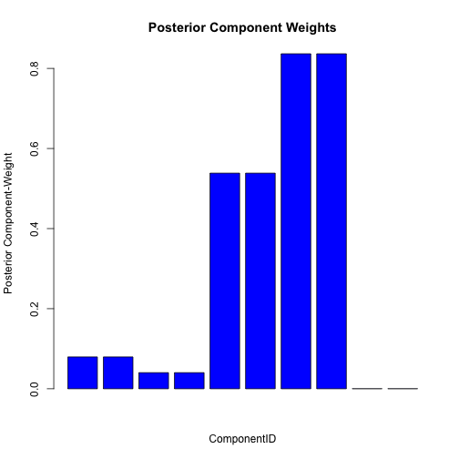

```r
mix=mixture.dist(p=1,nts=9)
post.weight=mix$posterior.weights
component.means=mix$component.means
component.vars=mix$component.vars
barplot(post.weight[,1],ylab="Posterior Component-Weight",xlab="ComponentID",main="Posterior Component Weights",col="blue")
```

Then, we can choose which distribution to examine by calling considering the distributions of weights and choosing \( \beta \) to arise from one of these according to the multinomial.

```r
set.seed(100)
component=which(rmultinom(1,1,prob=post.weight)==1)
print(component)
```

```
## [1] 7
```

Which shows our beta to be from component 7. Thus the distribution we expect for our \( \beta \) is coming from the following distribution with mean vector and variance matrix:

```r
r=rmvnorm(100000,mean=component.means[[7]],component.vars[[7]])
component.means[[component]]
```

```
##            [,1]
##  [1,] -0.101562
##  [2,]  0.084140
##  [3,]  0.087395
##  [4,] -0.083268
##  [5,] -0.099651
##  [6,] -0.103920
##  [7,]  0.008849
##  [8,]  0.109624
##  [9,]  0.018479
```

```r
component.vars[[component]]
```

```
##           [,1]     [,2]     [,3]     [,4]     [,5]     [,6]     [,7]
##  [1,] 0.070811 0.004878 0.004703 0.004931 0.004792 0.004916 0.004700
##  [2,] 0.004878 0.071392 0.004739 0.004969 0.004829 0.004954 0.004736
##  [3,] 0.004703 0.004739 0.068664 0.004791 0.004656 0.004776 0.004566
##  [4,] 0.004931 0.004969 0.004791 0.072219 0.004881 0.005008 0.004787
##  [5,] 0.004792 0.004829 0.004656 0.004881 0.070049 0.004867 0.004652
##  [6,] 0.004916 0.004954 0.004776 0.005008 0.004867 0.071990 0.004773
##  [7,] 0.004700 0.004736 0.004566 0.004787 0.004652 0.004773 0.068612
##  [8,] 0.004986 0.005024 0.004844 0.005079 0.004936 0.005063 0.004841
##  [9,] 0.004861 0.004898 0.004723 0.004951 0.004812 0.004937 0.004719
##           [,8]     [,9]
##  [1,] 0.004986 0.004861
##  [2,] 0.005024 0.004898
##  [3,] 0.004844 0.004723
##  [4,] 0.005079 0.004951
##  [5,] 0.004936 0.004812
##  [6,] 0.005063 0.004937
##  [7,] 0.004841 0.004719
##  [8,] 0.073083 0.005007
##  [9,] 0.005007 0.071126
```

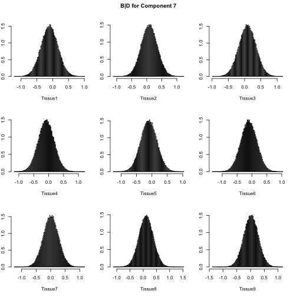

```r
par( mfrow = c( 3, 3 ), oma = c( 0, 0, 2, 0 ),mar=c(5,2,2,2) )

for(x in 1:nts){hist(r[,x],main="",freq=F,breaks=100,xlab=paste0("Tissue",x))}

title( "B|D for Component 7", outer = TRUE )
```

The vector \( \mathbf r \) contains a set of randomly generated \( \beta_{gp} \) drawn from the 7th component of our posterior distribution, according to the posterior weights and the corrresponding mean vector and posterior variance.

Below, I've created a function to output a plot of B|D for a user-inputted SNP-gene pair.

```
## [1] "Your Beta is coming from component 1"
```

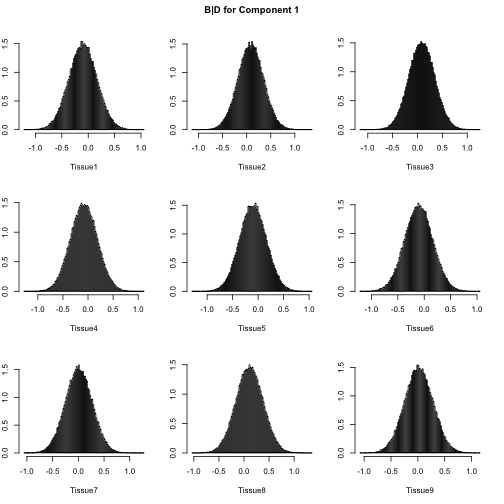

```r
posterior.plot=function(component.means,component.vars){
  component=which(rmultinom(1,1,prob=post.weight)==1)
print(paste0("Your Beta is coming from component ",component))
r=rmvnorm(100000,mean=component.means[[7]],component.vars[[7]])
component.means[[component]]
component.vars[[component]]
par( mfrow = c( 3, 3 ), oma = c( 0, 0, 2, 0 ),mar=c(5,2,2,2) )

for(x in 1:nts){hist(r[,x],main="",freq=F,breaks=100,xlab=paste0("Tissue",x))}

title( paste0("B|D for Component ",component), outer = TRUE )
}

posterior.plot(component.means,component.vars)
```